# Preprocessing sample 3

## Import the packages necessary to run this python notebook

We will use *scanpy* as the main analysis tool for the analysis. Scanpy has a comprehensive [manual webpage](https://scanpy.readthedocs.io/en/stable/) that includes many different tutorial you can use for further practicing. Scanpy is used in the discussion paper and the tutorial paper of this course. An alternative and well-established tool for R users is [Seurat](https://satijalab.org/seurat/). However, scanpy is mainatined and updated by a wider community with many of the latest developed tools.

```python
import scanpy as sc
import pandas as pd
import scvelo as scv
import numpy as np
import seaborn as sns
import matplotlib.pyplot as plt
import sklearn
```

import scanpy as sc import pandas as pd import scvelo as scv import numpy as np import seaborn as sns import matplotlib.pyplot as plt import sklearn

## Loading and understanding the dataset

There are many different possible formats. Each format has a dedicated reading command in scanpy, for example `read_h5ad`, `read_10X` ....

Each dataset is opened and an `Annotated data` object is created. This object contains:

- The data matrix `adata.X` of size $N\_cells \times N\_genes$
- Vectors of cells-related variables in the dataframe `adata.obs`
- Vectors of genes-related variables in the dataframe `adata.var`
- Matrices of size $N\_cells \times N\_genes$ in `adata.layers`
- Matrices where each line is cell-related in `adata.obsm`
- Matrices where each line is gene-related in `adata.varm`
- Anything else that must be saved is in `adata.uns`

The cells are called observations (obs) and the genes variables (var).

[figure not shown]

https://www.nature.com/articles/s41598-020-67513-5 useful for filtering explanation with spliced/unspliced reads

```python
sample_3 = sc.read_10x_mtx('../data/cellranger/cellranger_sample3/outs/filtered_feature_bc_matrix/', cache=True)
```

sample_3 = sc.read_10x_mtx('../data/cellranger/cellranger_sample3/outs/filtered_feature_bc_matrix/', cache=True)

```python
spl_sample_3 = scv.read_loom('../data/cellranger/velocyto_sample3/possorted_genome_bam.loom')
```

spl_sample_3 = scv.read_loom('../data/cellranger/velocyto_sample3/possorted_genome_bam.loom')

```
Variable names are not unique. To make them unique, call `.var_names_make_unique`.
```

```python
del spl_sample_3.layers['matrix']
```

del spl_sample_3.layers['matrix']

```python
sample_3 = scv.utils.merge( sample_3, spl_sample_3 )
```

sample_3 = scv.utils.merge( sample_3, spl_sample_3 )

```python
del spl_sample_3
```

del spl_sample_3

```python
sample_3
```

sample_3

```
AnnData object with n_obs × n_vars = 7639 × 36601
    obs: 'initial_size_spliced', 'initial_size_unspliced', 'initial_size'
    var: 'gene_ids', 'feature_types', 'Accession', 'Chromosome', 'End', 'Start', 'Strand'
    layers: 'ambiguous', 'spliced', 'unspliced'
```

```python
sample_3.write('../data/notebooks_data/sample_3.h5ad')
```

sample_3.write('../data/notebooks_data/sample_3.h5ad')

```
... storing 'feature_types' as categorical
... storing 'Chromosome' as categorical
... storing 'Strand' as categorical
```

We do the filtering one dataset at a time

```python
sample_3 = sc.read('../data/notebooks_data/sample_3.h5ad')
```

sample_3 = sc.read('../data/notebooks_data/sample_3.h5ad')

```python
sample_3.X = np.array(sample_3.X.todense()).copy()
```

sample_3.X = np.array(sample_3.X.todense()).copy()

```python
sc.preprocessing.calculate_qc_metrics(sample_3, inplace=True)
```

sc.preprocessing.calculate_qc_metrics(sample_3, inplace=True)

```python
sample_3
```

sample_3

```
AnnData object with n_obs × n_vars = 7639 × 36601
    obs: 'initial_size_spliced', 'initial_size_unspliced', 'initial_size', 'n_genes_by_counts', 'log1p_n_genes_by_counts', 'total_counts', 'log1p_total_counts', 'pct_counts_in_top_50_genes', 'pct_counts_in_top_100_genes', 'pct_counts_in_top_200_genes', 'pct_counts_in_top_500_genes'
    var: 'gene_ids', 'feature_types', 'Accession', 'Chromosome', 'End', 'Start', 'Strand', 'n_cells_by_counts', 'mean_counts', 'log1p_mean_counts', 'pct_dropout_by_counts', 'total_counts', 'log1p_total_counts'
    layers: 'ambiguous', 'spliced', 'unspliced'
```

```python
sample_3.obs
```

sample_3.obs

|  | initial_size_spliced | initial_size_unspliced | initial_size | n_genes_by_counts | log1p_n_genes_by_counts | total_counts | log1p_total_counts | pct_counts_in_top_50_genes | pct_counts_in_top_100_genes | pct_counts_in_top_200_genes | pct_counts_in_top_500_genes |
| --- | --- | --- | --- | --- | --- | --- | --- | --- | --- | --- | --- |
| AAACCTGAGGAGTCTG | 449 | 181 | 449.0 | 427 | 6.059123 | 643.0 | 6.467699 | 37.636081 | 49.144635 | 64.696734 | 100.000000 |
| AAACCTGAGGCATGTG | 1171 | 102 | 1171.0 | 937 | 6.843750 | 1460.0 | 7.286876 | 21.986301 | 32.602740 | 46.780822 | 70.068493 |
| AAACCTGAGTGAAGAG | 10224 | 1439 | 10224.0 | 4034 | 8.302762 | 12218.0 | 9.410748 | 19.364872 | 25.904403 | 35.054837 | 51.735145 |
| AAACCTGCAATAGCGG | 790 | 66 | 790.0 | 734 | 6.599870 | 975.0 | 6.883462 | 20.512821 | 30.769231 | 45.230769 | 76.000000 |
| AAACCTGCACGGACAA | 699 | 64 | 699.0 | 655 | 6.486161 | 943.0 | 6.850126 | 29.798515 | 40.402969 | 51.749735 | 83.563097 |
| ... | ... | ... | ... | ... | ... | ... | ... | ... | ... | ... | ... |
| TTTGTCATCACAGGCC | 29775 | 5366 | 29775.0 | 7282 | 8.893298 | 36957.0 | 10.517537 | 12.841951 | 19.235869 | 28.027167 | 43.886138 |
| TTTGTCATCCAAATGC | 2082 | 1119 | 2082.0 | 1818 | 7.506042 | 2782.0 | 7.931285 | 17.613228 | 24.335011 | 33.752696 | 52.624012 |
| TTTGTCATCCGGCACA | 5490 | 1163 | 5490.0 | 3111 | 8.043021 | 6741.0 | 8.816112 | 14.063195 | 21.154131 | 31.330663 | 48.805815 |
| TTTGTCATCGACAGCC | 9187 | 3373 | 9187.0 | 4107 | 8.320692 | 12010.0 | 9.393579 | 24.754371 | 35.278934 | 44.462948 | 57.360533 |
| TTTGTCATCGCAGGCT | 1836 | 1581 | 1836.0 | 1551 | 7.347300 | 2267.0 | 7.726654 | 15.483017 | 22.143802 | 32.730481 | 53.639171 |

7639 rows × 11 columns

```python
sample_3.var
```

sample_3.var

|  | gene_ids | feature_types | Accession | Chromosome | End | Start | Strand | n_cells_by_counts | mean_counts | log1p_mean_counts | pct_dropout_by_counts | total_counts | log1p_total_counts |
| --- | --- | --- | --- | --- | --- | --- | --- | --- | --- | --- | --- | --- | --- |
| MIR1302-2HG | ENSG00000243485 | Gene Expression | ENSG00000243485 | 1 | 31109 | 29554 | + | 36 | 0.005236 | 0.005223 | 99.528734 | 40.0 | 3.713572 |
| FAM138A | ENSG00000237613 | Gene Expression | ENSG00000237613 | 1 | 36081 | 34554 | - | 0 | 0.000000 | 0.000000 | 100.000000 | 0.0 | 0.000000 |
| OR4F5 | ENSG00000186092 | Gene Expression | ENSG00000186092 | 1 | 71585 | 65419 | + | 0 | 0.000000 | 0.000000 | 100.000000 | 0.0 | 0.000000 |
| AL627309.1 | ENSG00000238009 | Gene Expression | ENSG00000238009 | 1 | 133723 | 89295 | - | 16 | 0.002095 | 0.002092 | 99.790549 | 16.0 | 2.833213 |
| AL627309.3 | ENSG00000239945 | Gene Expression | ENSG00000239945 | 1 | 91105 | 89551 | - | 0 | 0.000000 | 0.000000 | 100.000000 | 0.0 | 0.000000 |
| ... | ... | ... | ... | ... | ... | ... | ... | ... | ... | ... | ... | ... | ... |
| AC141272.1 | ENSG00000277836 | Gene Expression | ENSG00000277836 | KI270728.1 | 1271271 | 1270984 | + | 0 | 0.000000 | 0.000000 | 100.000000 | 0.0 | 0.000000 |
| AC023491.2 | ENSG00000278633 | Gene Expression | ENSG00000278633 | KI270731.1 | 13001 | 10598 | - | 638 | 0.373085 | 0.317060 | 91.648121 | 2850.0 | 7.955425 |
| AC007325.1 | ENSG00000276017 | Gene Expression | ENSG00000276017 | KI270734.1 | 74814 | 72411 | + | 274 | 0.063359 | 0.061433 | 96.413143 | 484.0 | 6.184149 |
| AC007325.4 | ENSG00000278817 | Gene Expression | ENSG00000278817 | KI270734.1 | 137392 | 131494 | + | 741 | 0.125671 | 0.118379 | 90.299777 | 960.0 | 6.867974 |
| AC007325.2 | ENSG00000277196 | Gene Expression | ENSG00000277196 | KI270734.1 | 161852 | 138082 | - | 2 | 0.000262 | 0.000262 | 99.973819 | 2.0 | 1.098612 |

36601 rows × 13 columns

```python
sample_3.var['Chromosome'].value_counts()
```

sample_3.var['Chromosome'].value_counts()

```
1             3410
2             2541
11            2065
19            2027
17            1992
12            1928
3             1893
6             1827
5             1811
7             1686
16            1649
4             1533
8             1495
14            1474
10            1394
9             1319
15            1267
X             1148
20             964
22             901
13             788
18             781
21             555
Y              111
M               13
KI270728.1       6
KI270727.1       4
KI270734.1       3
GL000195.1       2
KI270726.1       2
GL000194.1       2
KI270713.1       2
KI270711.1       1
GL000219.1       1
GL000218.1       1
KI270731.1       1
GL000213.1       1
GL000205.2       1
GL000009.2       1
KI270721.1       1
Name: Chromosome, dtype: int64
```

```python
sample_3.var['mean_counts']
```

sample_3.var['mean_counts']

```
MIR1302-2HG    0.005236
FAM138A        0.000000
OR4F5          0.000000
AL627309.1     0.002095
AL627309.3     0.000000
                 ...
AC141272.1     0.000000
AC023491.2     0.373085
AC007325.1     0.063359
AC007325.4     0.125671
AC007325.2     0.000262
Name: mean_counts, Length: 36601, dtype: float32
```

```python
MT = ['M' in i for i in sample_3.var['Chromosome']]
perc_mito = np.sum( sample_3[:,MT].X, 1 ) / np.sum( sample_3.X, 1 )
sample_3.obs['perc_mito'] = perc_mito.copy()
```

MT = ['M' in i for i in sample_3.var['Chromosome']] perc_mito = np.sum( sample_3[:,MT].X, 1 ) / np.sum( sample_3.X, 1 ) sample_3.obs['perc_mito'] = perc_mito.copy()

```python
perc_mito
```

perc_mito

```
ArrayView([0.06531882, 0.00821918, 0.00065477, ..., 0.00044504,
           0.02889259, 0.00220556], dtype=float32)
```

```python
prop_spliced = np.sum(sample_3.layers['spliced'].todense(), 1).A1 / ( np.sum(sample_3.layers['spliced'].todense()+sample_3.layers['unspliced'].todense(), 1).A1 )
```

prop_spliced = np.sum(sample_3.layers['spliced'].todense(), 1).A1 / ( np.sum(sample_3.layers['spliced'].todense()+sample_3.layers['unspliced'].todense(), 1).A1 )

```python
prop_spliced
```

prop_spliced

```
array([0.71269841, 0.91987431, 0.87661837, ..., 0.82519164, 0.73144904,
       0.53731343])
```

```python
sample_3.obs['prop_spliced'] = pd.Series(prop_spliced, index=sample_3.obs_names)
```

sample_3.obs['prop_spliced'] = pd.Series(prop_spliced, index=sample_3.obs_names)

```python
prop_unspliced = np.sum(sample_3.layers['unspliced'].todense(), 1).A1 / ( np.sum(sample_3.layers['spliced'].todense()+sample_3.layers['unspliced'].todense(), 1).A1 )
```

prop_unspliced = np.sum(sample_3.layers['unspliced'].todense(), 1).A1 / ( np.sum(sample_3.layers['spliced'].todense()+sample_3.layers['unspliced'].todense(), 1).A1 )

```python
prop_unspliced
```

prop_unspliced

```
array([0.28730159, 0.08012569, 0.12338163, ..., 0.17480836, 0.26855096,
       0.46268657])
```

```python
sample_3.obs['prop_unspliced'] = pd.Series(prop_unspliced, index=sample_3.obs_names)
```

sample_3.obs['prop_unspliced'] = pd.Series(prop_unspliced, index=sample_3.obs_names)

```python
sc.pl.scatter(sample_3, x='total_counts', y='n_genes_by_counts', color='perc_mito')
```

sc.pl.scatter(sample_3, x='total_counts', y='n_genes_by_counts', color='perc_mito')

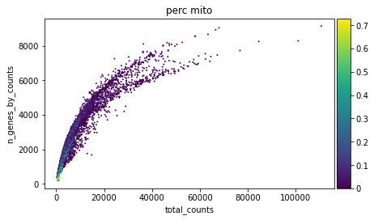

```python
sc.pl.scatter(sample_3, x='total_counts', y='n_genes_by_counts', color='prop_unspliced')
```

sc.pl.scatter(sample_3, x='total_counts', y='n_genes_by_counts', color='prop_unspliced')

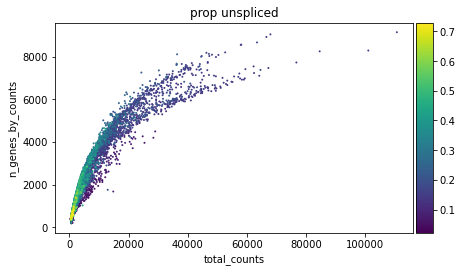

```python
plt.rcParams['figure.figsize'] = (16,6)
f, ax = plt.subplots(1,3)

sns.distplot(sample_3.obs['total_counts'], ax=ax[0], bins=50)
ax[0].axvline(5000, color='red', linewidth=2)
ax[0].set_title('Distribution of total transcripts per cell')

sns.distplot(sample_3.obs['n_genes_by_counts'], ax=ax[1], bins=50)
ax[1].axvline(2000, color='red', linewidth=2)
#ax[1].axvline(3000, color='red', linewidth=2)
ax[1].set_title('Distribution of number of genes detected per cell')

sns.distplot(sample_3.obs['perc_mito'], ax=ax[2], bins=50)
ax[2].axvline(0.2, color='red', linewidth=2)
ax[2].set_title('Distribution of MT genes percentage per cell')
```

plt.rcParams['figure.figsize'] = (16,6) f, ax = plt.subplots(1,3) sns.distplot(sample_3.obs['total_counts'], ax=ax[0], bins=50) ax[0].axvline(5000, color='red', linewidth=2) ax[0].set_title('Distribution of total transcripts per cell') sns.distplot(sample_3.obs['n_genes_by_counts'], ax=ax[1], bins=50) ax[1].axvline(2000, color='red', linewidth=2) #ax[1].axvline(3000, color='red', linewidth=2) ax[1].set_title('Distribution of number of genes detected per cell') sns.distplot(sample_3.obs['perc_mito'], ax=ax[2], bins=50) ax[2].axvline(0.2, color='red', linewidth=2) ax[2].set_title('Distribution of MT genes percentage per cell')

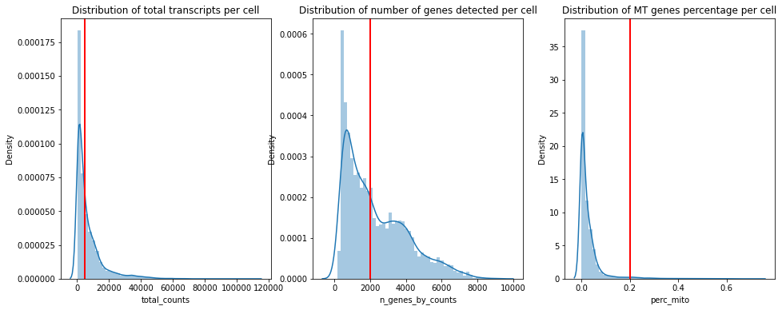

```python
sns.distplot(sample_3[sample_3.obs['total_counts']<10000].obs['prop_spliced'], bins=50)
```

sns.distplot(sample_3[sample_3.obs['total_counts']<10000].obs['prop_spliced'], bins=50)

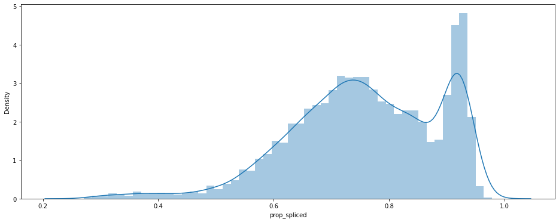

```python
sns.distplot(sample_3.obs['n_genes_by_counts'], bins=50)
```

sns.distplot(sample_3.obs['n_genes_by_counts'], bins=50)

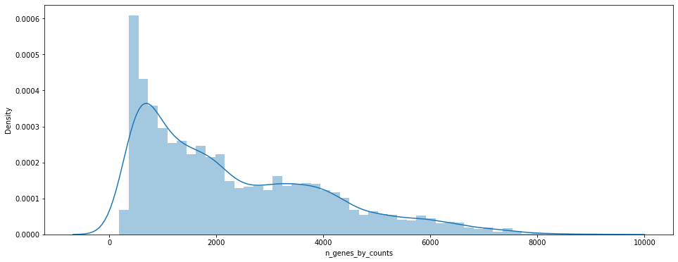

```python
sc.preprocessing.filter_cells(sample_3, max_counts=40000)

sc.preprocessing.filter_cells(sample_3, min_counts=2000)

sc.preprocessing.filter_cells(sample_3, min_genes=1500)

sc.preprocessing.filter_cells(sample_3, max_genes=8000)
```

sc.preprocessing.filter_cells(sample_3, max_counts=40000) sc.preprocessing.filter_cells(sample_3, min_counts=2000) sc.preprocessing.filter_cells(sample_3, min_genes=1500) sc.preprocessing.filter_cells(sample_3, max_genes=8000)

```python
sc.preprocessing.filter_genes(sample_3, min_cells=10)
```

sc.preprocessing.filter_genes(sample_3, min_cells=10)

```python
sample_3
```

sample_3

```
AnnData object with n_obs × n_vars = 4315 × 24577
    obs: 'initial_size_spliced', 'initial_size_unspliced', 'initial_size', 'n_genes_by_counts', 'log1p_n_genes_by_counts', 'total_counts', 'log1p_total_counts', 'pct_counts_in_top_50_genes', 'pct_counts_in_top_100_genes', 'pct_counts_in_top_200_genes', 'pct_counts_in_top_500_genes', 'perc_mito', 'pr…
    var: 'gene_ids', 'feature_types', 'Accession', 'Chromosome', 'End', 'Start', 'Strand', 'n_cells_by_counts', 'mean_counts', 'log1p_mean_counts', 'pct_dropout_by_counts', 'total_counts', 'log1p_total_counts', 'n_cells'
    layers: 'ambiguous', 'spliced', 'unspliced'
```

```python
sc.external.pp.scrublet(sample_3, expected_doublet_rate=0.06, threshold=.2, random_state=12345)
```

sc.external.pp.scrublet(sample_3, expected_doublet_rate=0.06, threshold=.2, random_state=12345)

```
Detected doublet rate = 3.4%
Estimated detectable doublet fraction = 68.0%
Overall doublet rate:
	Expected   = 6.0%
	Estimated  = 5.0%
```

```python
sns.distplot(sample_3.obs['doublet_score'])
```

sns.distplot(sample_3.obs['doublet_score'])

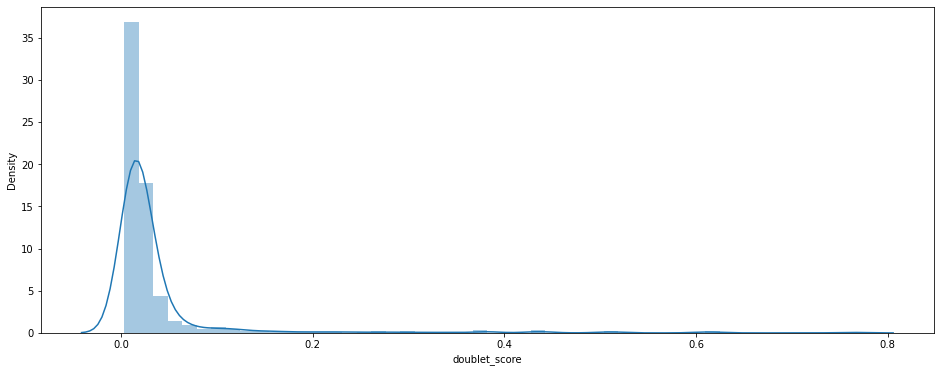

```python
sample_3 = sample_3[np.invert(sample_3.obs['predicted_doublet'])].copy()
```

sample_3 = sample_3[np.invert(sample_3.obs['predicted_doublet'])].copy()

```python
# save raw sample_3 matrix
sample_3.layers['raw_counts'] = sample_3.X.copy()

# TPM normalization and matrix copy
sc.pp.normalize_per_cell(sample_3)
sample_3.layers['tpm_counts'] = sample_3.X.copy()

# matrix logarithmization and copy
sc.pp.log1p(sample_3)
sample_3.layers['log_counts'] = sample_3.X.copy()

sc.pp.highly_variable_genes(sample_3, n_top_genes=15000)

sample_3.write('../data/notebooks_data/sample_3.filt.h5ad')

# standardized gene expressions and matrix copy
sc.pp.scale(sample_3)
sample_3.layers['gauss_counts'] = sample_3.X.copy()



sc.preprocessing.pca(sample_3, svd_solver='arpack', random_state=12345)

sample_3

sc.plotting.pca_variance_ratio(sample_3)
```

# save raw sample_3 matrix sample_3.layers['raw_counts'] = sample_3.X.copy() # TPM normalization and matrix copy sc.pp.normalize_per_cell(sample_3) sample_3.layers['tpm_counts'] = sample_3.X.copy() # matrix logarithmization and copy sc.pp.log1p(sample_3) sample_3.layers['log_counts'] = sample_3.X.copy() sc.pp.highly_variable_genes(sample_3, n_top_genes=15000) sample_3.write('../data/notebooks_data/sample_3.filt.h5ad') # standardized gene expressions and matrix copy sc.pp.scale(sample_3) sample_3.layers['gauss_counts'] = sample_3.X.copy() sc.preprocessing.pca(sample_3, svd_solver='arpack', random_state=12345) sample_3 sc.plotting.pca_variance_ratio(sample_3)

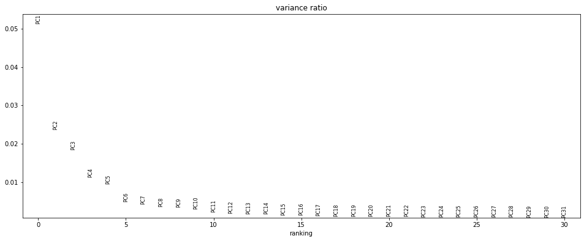

```python
plt.rcParams['figure.figsize'] = (6,6) #reduce figure size
sc.pl.pca(sample_3, color=['total_counts','SYCP1'])

sc.pp.neighbors(sample_3)

sc.tools.umap(sample_3, random_state=54321, n_components=2)

sc.plotting.umap(sample_3, color=['total_counts','prop_spliced'])
```

plt.rcParams['figure.figsize'] = (6,6) #reduce figure size sc.pl.pca(sample_3, color=['total_counts','SYCP1']) sc.pp.neighbors(sample_3) sc.tools.umap(sample_3, random_state=54321, n_components=2) sc.plotting.umap(sample_3, color=['total_counts','prop_spliced'])

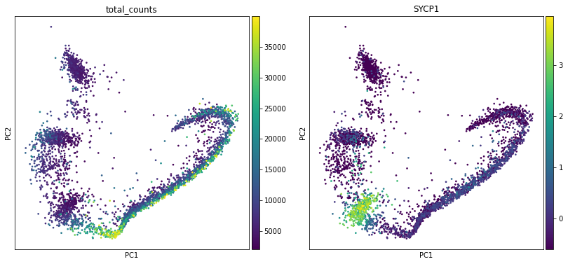

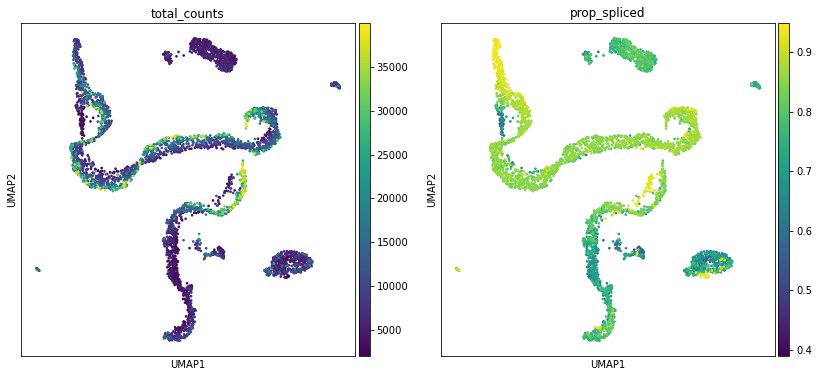

Concatenate the three datasets into one, and distinguish them with an identifier (`batch_categories`) having a name for the three samples

```python
data = sc.AnnData.concatenate(sample_1,sample_3,sample_3,
                              batch_categories=["Sample_1","sample_3","Sample_3"])
```

data = sc.AnnData.concatenate(sample_1,sample_3,sample_3, batch_categories=["Sample_1","sample_3","Sample_3"])

```python
data.obs_names_make_unique()
```

data.obs_names_make_unique()

```python
data.obs.value_counts()
```

data.obs.value_counts()

[output not shown]

We calculate quality measures to fill the object `adata` with some observations and variables

```python
sc.preprocessing.calculate_qc_metrics(data, inplace=True)
```

sc.preprocessing.calculate_qc_metrics(data, inplace=True)

We can see that now `data` contains many observations (`obs`) and variables (`var`). Those can be used for filtering and analysis purpose, as well as they might be needed by some scanpy tools

```python
data
```

data

```
AnnData object with n_obs × n_vars = 15547 × 56981
    obs: 'batch', 'n_genes_by_counts', 'log1p_n_genes_by_counts', 'total_counts', 'log1p_total_counts', 'pct_counts_in_top_50_genes', 'pct_counts_in_top_100_genes', 'pct_counts_in_top_200_genes', 'pct_counts_in_top_500_genes'
    var: 'n_cells_by_counts', 'mean_counts', 'log1p_mean_counts', 'pct_dropout_by_counts', 'total_counts', 'log1p_total_counts'
```

observations are accessed through `data.obs`, which is a dataframe, i.e. a table with indexes on the rows (cell barcodes) and column names (the observation types). One can select a specific observation type by indexing it in the table

```python
data.obs
```

data.obs

|  | batch | n_genes_by_counts | log1p_n_genes_by_counts | total_counts | log1p_total_counts | pct_counts_in_top_50_genes | pct_counts_in_top_100_genes | pct_counts_in_top_200_genes | pct_counts_in_top_500_genes |
| --- | --- | --- | --- | --- | --- | --- | --- | --- | --- |
| GACGTGCGTTTGGCGC-Sample_1 | Sample_1 | 7197 | 8.881558 | 35299.003906 | 10.471639 | 13.765706 | 20.623674 | 29.907709 | 46.482453 |
| GTCACAACAGTATGCT-Sample_1 | Sample_1 | 6562 | 8.789203 | 39455.000000 | 10.582941 | 16.937271 | 24.827028 | 35.080477 | 51.865156 |
| CCATTCGAGGTGCAAC-Sample_1 | Sample_1 | 7652 | 8.942853 | 42045.000000 | 10.646520 | 13.520461 | 20.349894 | 29.780970 | 46.103480 |
| CGCGGTACACAACGTT-Sample_1 | Sample_1 | 6455 | 8.772765 | 38708.000000 | 10.563828 | 16.694032 | 24.522073 | 35.031689 | 52.434386 |
| GTCAAGTAGTAATCCC-Sample_1 | Sample_1 | 6921 | 8.842460 | 47450.000000 | 10.767453 | 16.182015 | 23.897787 | 33.905093 | 50.921812 |
| ... | ... | ... | ... | ... | ... | ... | ... | ... | ... |
| CTAGAGTTCGCTGATA-Sample_3 | Sample_3 | 1405 | 7.248504 | 2970.000000 | 7.996654 | 32.424242 | 44.882146 | 56.565640 | 71.481465 |
| ACGCAGCAGGCAGTCA-Sample_3 | Sample_3 | 1408 | 7.250636 | 2873.000000 | 7.963460 | 35.850908 | 45.074692 | 54.681375 | 69.926763 |
| GATCGATAGTTGAGTA-Sample_3 | Sample_3 | 1486 | 7.304516 | 2912.000000 | 7.976939 | 28.571426 | 40.143992 | 51.785475 | 68.131629 |
| ACAGCTAGTGTTAAGA-Sample_3 | Sample_3 | 1749 | 7.467371 | 2573.000000 | 7.853216 | 17.486670 | 24.941246 | 35.081877 | 54.527401 |
| CAGGTGCCATACTCTT-Sample_3 | Sample_3 | 1189 | 7.081709 | 3622.000000 | 8.195058 | 51.905025 | 60.270569 | 69.425732 | 82.689122 |

15547 rows × 9 columns

```python
data.obs['batch'].head() #sample label - the data contains three separate samples
```

data.obs['batch'].head() #sample label - the data contains three separate samples

[output not shown]

`data.var` works similarly, but now each row is referred to a gene

```python
data.var
```

data.var

|  | n_cells_by_counts | mean_counts | log1p_mean_counts | pct_dropout_by_counts | total_counts | log1p_total_counts |
| --- | --- | --- | --- | --- | --- | --- |
| DDX11L1 | 1036 | 0.031475 | 0.030989 | 93.336335 | 489.335632 | 6.195090 |
| WASH7P | 91 | 0.003996 | 0.003988 | 99.414678 | 62.119141 | 4.145024 |
| MIR6859-1 | 0 | 0.000000 | 0.000000 | 100.000000 | 0.000000 | 0.000000 |
| MIR1302-2HG | 1370 | 0.059563 | 0.057856 | 91.188011 | 926.024841 | 6.831980 |
| MIR1302-2 | 0 | 0.000000 | 0.000000 | 100.000000 | 0.000000 | 0.000000 |
| ... | ... | ... | ... | ... | ... | ... |
| MT-ND6 | 669 | 0.049270 | 0.048095 | 95.696919 | 766.000000 | 6.642487 |
| MT-TE | 0 | 0.000000 | 0.000000 | 100.000000 | 0.000000 | 0.000000 |
| MT-CYB | 8818 | 5.852576 | 1.924625 | 43.281662 | 90990.000000 | 11.418516 |
| MT-TT | 0 | 0.000000 | 0.000000 | 100.000000 | 0.000000 | 0.000000 |
| MT-TP | 0 | 0.000000 | 0.000000 | 100.000000 | 0.000000 | 0.000000 |

56981 rows × 6 columns

```python
data.var['n_cells_by_counts'].head() #nr of cells where transcripts of a gene are observed
```

data.var['n_cells_by_counts'].head() #nr of cells where transcripts of a gene are observed

```
DDX11L1        1036
WASH7P           91
MIR6859-1         0
MIR1302-2HG    1370
MIR1302-2         0
Name: n_cells_by_counts, dtype: int64
```